# Practice test 2

Cargando la libreria

```r
library(ggplot2)
library(dplyr)
library(tidyr)
library(rlang)
library(nycflights13)
#weather
View(weather)
#flights
View(flights)
#planes
View(planes)
#airlines
View(airlines)
#airports
View(airports)
```

1. Inner-join

1.1 Conecte flights con planes

```r
flights_planes <- flights %>%
  inner_join(planes, by = "tailnum")
```

```r
flights_airlines <- flights %>%
  inner_join(airlines, by = "carrier")
```

```r
flights_airports_origin <- flights %>%
  inner_join(airports, by = c("origin" = "faa"))

flights_airports_dest <- flights %>%
  inner_join(airports, by = c("dest" = "faa"))

flights_n_airports <- flights %>%
  inner_join(airports, by = c("origin" = "faa")) %>%
  inner_join(airports, by = c("dest" = "faa"))
```

2. Data manipulation

2.1 Utilice el verbo count en flights y envíe como parámetro las variables year, month, day. Luego filtre n para que sea mayor a 1000. Por último ordene n con el verbo arrange y devuelva el resultado.

```r
flights_count <- flights %>%
  count(year, month, day) %>%
  filter(n > 1000) %>%
  arrange(n)

print(flights_count)
```

| year | month | day | n |
| --- | --- | --- | --- |
| 2013 | 7 | 9 | 1001 |
| 2013 | 7 | 17 | 1001 |
| 2013 | 7 | 31 | 1001 |
| 2013 | 8 | 7 | 1001 |
| 2013 | 8 | 8 | 1001 |
| 2013 | 8 | 12 | 1001 |
| 2013 | 7 | 12 | 1002 |
| 2013 | 7 | 18 | 1003 |
| 2013 | 7 | 25 | 1003 |
| 2013 | 7 | 8 | 1004 |

[output cut: 4 more lines]

```r
NA
```

2.2 Utilice el concepto de selección por rango (aplicando el operador “:”) para obtener las variables year hacia day. También agregue a esta selección hour, origin, dest, tailnum, carrier, arr_delay, dep_delay, por último almacene el resultado en la variable flights_selected.

```r
flights_selected <- flights %>%
  select(year:day, hour, origin, dest, tailnum, carrier, arr_delay, dep_delay)

print(flights_selected)
```

| year | month | day | hour | origin | dest | tailnum | carrier | arr_delay | dep_delay |
| --- | --- | --- | --- | --- | --- | --- | --- | --- | --- |
| 2013 | 1 | 1 | 5 | EWR | IAH | N14228 | UA | 11 | 2 |
| 2013 | 1 | 1 | 5 | LGA | IAH | N24211 | UA | 20 | 4 |
| 2013 | 1 | 1 | 5 | JFK | MIA | N619AA | AA | 33 | 2 |
| 2013 | 1 | 1 | 5 | JFK | BQN | N804JB | B6 | -18 | -1 |
| 2013 | 1 | 1 | 6 | LGA | ATL | N668DN | DL | -25 | -6 |
| 2013 | 1 | 1 | 5 | EWR | ORD | N39463 | UA | 12 | -4 |
| 2013 | 1 | 1 | 6 | EWR | FLL | N516JB | B6 | 19 | -5 |
| 2013 | 1 | 1 | 6 | LGA | IAD | N829AS | EV | -14 | -3 |
| 2013 | 1 | 1 | 6 | JFK | MCO | N593JB | B6 | -8 | -3 |
| 2013 | 1 | 1 | 6 | LGA | ORD | N3ALAA | AA | 8 | -2 |

[output cut: 990 more lines]

```r
NA
```

2.3 Utilice left_join para combinar airlines y flights_selected. Al obtener el resultado, utilice el verbo select para eliminar las columnas origin y dest (utilice el operador “-” para descartar estas columnas únicamente). Por último agregue una nueva columna con el verbo mutate, asigne el nombre tot_delay y opere la suma de arr_delay y dep_delay

```r
mutated_flights_and_airlines <- flights_selected %>%
  left_join(airlines, by = "carrier") %>%
  select(-origin, -dest) %>%
  mutate(tot_delay = arr_delay + dep_delay)

print(mutated_flights_and_airlines)
```

| year | month | day | hour | tailnum | carrier | arr_delay | dep_delay | name | tot_delay |
| --- | --- | --- | --- | --- | --- | --- | --- | --- | --- |
| 2013 | 1 | 1 | 5 | N14228 | UA | 11 | 2 | United Air Lines Inc. | 13 |
| 2013 | 1 | 1 | 5 | N24211 | UA | 20 | 4 | United Air Lines Inc. | 24 |
| 2013 | 1 | 1 | 5 | N619AA | AA | 33 | 2 | American Airlines Inc. | 35 |
| 2013 | 1 | 1 | 5 | N804JB | B6 | -18 | -1 | JetBlue Airways | -19 |
| 2013 | 1 | 1 | 6 | N668DN | DL | -25 | -6 | Delta Air Lines Inc. | -31 |
| 2013 | 1 | 1 | 5 | N39463 | UA | 12 | -4 | United Air Lines Inc. | 8 |
| 2013 | 1 | 1 | 6 | N516JB | B6 | 19 | -5 | JetBlue Airways | 14 |
| 2013 | 1 | 1 | 6 | N829AS | EV | -14 | -3 | ExpressJet Airlines Inc. | -17 |
| 2013 | 1 | 1 | 6 | N593JB | B6 | -8 | -3 | JetBlue Airways | -11 |
| 2013 | 1 | 1 | 6 | N3ALAA | AA | 8 | -2 | American Airlines Inc. | 6 |

[output cut: 990 more lines]

2.4 Utilice inner_join para combinar flights y weather, luego agrupe por la variable precip. Utilice summarize para encontrar el promedio de la variable dep_delay (aplicando la función mean), asigne al promedio el nombre delay. Al utilizar la función mean agregue el parámetro na.rm y asígnele TRUE por defecto.

Luego agregue la función replace_na y aplíquelo a la variable delay sustituyendo NA por cero. Por último almacene el resultado en la variable precip_delay.

```r
flights_weather_dep_delay_mean <- flights %>%
  inner_join(weather, by = c("year", "month", "day", "hour", "origin")) %>%
  group_by(precip) %>%
  summarize(delay = mean(dep_delay, na.rm = TRUE))

precip_delay <- flights_weather_dep_delay_mean %>%
  mutate(delay = replace_na(delay, 0))


print(precip_delay)
```

| precip | delay |
| --- | --- |
| 0.00 | 11.374509 |
| 0.01 | 29.802886 |
| 0.02 | 24.081196 |
| 0.03 | 28.739329 |
| 0.04 | 28.600265 |
| 0.05 | 29.379638 |
| 0.06 | 31.391616 |
| 0.07 | 27.703190 |
| 0.08 | 37.326172 |
| 0.09 | 40.211230 |

[output cut: 45 more lines]

2.5 Utilice la variable precip_delay para crear un gráfico de puntos tomando de eje x la variable precip y para y la variable delay

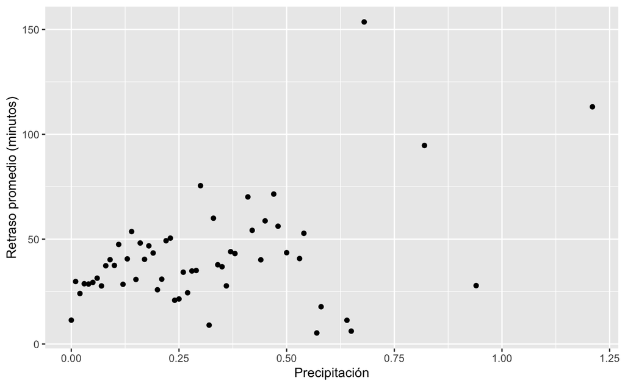

```r
precip_delay_graph <- ggplot(data = precip_delay, aes(x = precip, y = delay)) +
  geom_point() +
  labs(x = "Precipitación",
       y = "Retraso promedio (minutos)")

print(precip_delay_graph)
```

2.6 Utilice fligths y aplique filter tomando en cuenta la siguiente condición: Que year sea igual a 2013, que month sea igual a 5 y que day sea igual a 10. Luego agrupe por la variable dest. Después utilice summarize para obtener el promedio de la variable arr_delay, establezca el parámetro na.rm en TRUE y asigne al promedio el nombre de delay. Conecte el resultado anterior por medio de inner_join a la tabla airports y asignelo a la variable flights_airports.

```r
flights_airports <- flights %>%
  filter(year == 2013, month == 5, day == 10) %>%
  group_by(dest) %>%
  summarize(delay = mean(arr_delay, na.rm = TRUE)) %>%
  inner_join(airports, by = c("dest" = "faa"))

print(flights_airports)
```

| dest | delay | name | lat | lon | alt | tz | dst | tzone |
| --- | --- | --- | --- | --- | --- | --- | --- | --- |
| ABQ | 105.0000000 | Albuquerque International Sunport | 35.04022 | -106.60919 | 5355 | -7 | A | America/Denver |
| ALB | 26.5000000 | Albany Intl | 42.74827 | -73.80169 | 285 | -5 | A | America/New_York |
| ATL | 5.6800000 | Hartsfield Jackson Atlanta Intl | 33.63672 | -84.42807 | 1026 | -5 | A | America/New_York |
| AUS | 31.1666667 | Austin Bergstrom Intl | 30.19453 | -97.66989 | 542 | -6 | A | America/Chicago |
| AVL | -8.0000000 | Asheville Regional Airport | 35.43619 | -82.54181 | 2165 | -5 | A | America/New_York |
| BDL | -18.0000000 | Bradley Intl | 41.93889 | -72.68322 | 173 | -5 | A | America/New_York |
| BGR | -14.0000000 | Bangor Intl | 44.80744 | -68.82814 | 192 | -5 | A | America/New_York |
| BHM | 98.0000000 | Birmingham Intl | 33.56294 | -86.75355 | 644 | -6 | A | America/Chicago |
| BNA | 28.8421053 | Nashville Intl | 36.12447 | -86.67819 | 599 | -6 | A | America/Chicago |
| BOS | -0.3541667 | General Edward Lawrence Logan Intl | 42.36435 | -71.00518 | 19 | -5 | A | America/New_York |

[output cut: 73 more lines]

2.7 Utilice la variable flights_airports para crear un gráfico de puntos tomando de eje x la variable lon y para y la variable lat. Defina el color y el tamaño por medio de la variable delay. El tamaño se establece por medio del parámetro size.

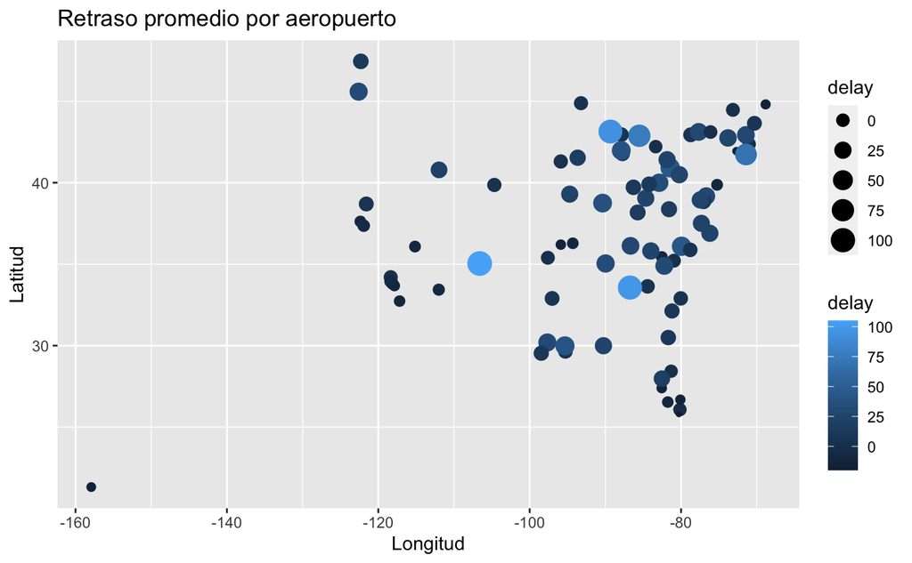

```r
flights_airports_graph <- ggplot(data = flights_airports, aes(x = lon, y = lat, color = delay, size = delay)) +
  geom_point() +
  labs(title = "Retraso promedio por aeropuerto",
       x = "Longitud",
       y = "Latitud")

print(flights_airports_graph)
```

2.8 Utilice inner_join para combinar flights y planes. Agregue los sufijos _flights y _planes respectivamente. Por último utilice la función transmute para seleccionar las variables tailnum y manufacturer, pero además agregue la variable pi que almacene la suma de dep_delay y arr_delay, y luego divida por air_time.

```r
transmuted_flights_planes <- nycflights13::flights %>%
  inner_join(nycflights13::planes, by = "tailnum", suffix = c("_flights", "_planes")) %>%
  transmute(tailnum = tailnum,
            manufacturer = manufacturer,
            pi = (dep_delay + arr_delay) / air_time)

print(transmuted_flights_planes)
```

| tailnum | manufacturer | pi |
| --- | --- | --- |
| N14228 | BOEING | 0.057268722 |
| N24211 | BOEING | 0.105726872 |
| N619AA | BOEING | 0.218750000 |
| N804JB | AIRBUS | -0.103825137 |
| N668DN | BOEING | -0.267241379 |
| N39463 | BOEING | 0.053333333 |
| N516JB | AIRBUS INDUSTRIE | 0.088607595 |
| N829AS | CANADAIR | -0.320754717 |
| N593JB | AIRBUS | -0.078571429 |
| N793JB | AIRBUS | -0.026845638 |

[output cut: 990 more lines]